# Data Science Using Python, SAS, & R

A Rosetta Stone for Analytical Languages

Elaine Kearney

# R Tutorial

Welcome to the R tutorial version of *Data Science Using Python, SAS, & R: A Rosetta Stone for Analytical Languages*. This tutorial includes examples of common data science tasks, organized in the same way across 3 data science languages. Before beginning this tutorial, please check to make sure you have R 3.3.1 installed (this is not required, but this was the release used to generate the following examples). Also, the following R packages are used throughout this tutorial. You may not need all of the following packages to fit your specific needs, but they are listed below, and also in Appendix Section 2 with more detail, for your information:

gdata | rjson | ggplot2 | dplyr | tree | randomForest | gbm | xgboost | e1071 | RSNNS | caret | kernlab | dbscan | kohonen | forecast | prophet

To install R packages you need to run the following in the R console:

```r
install.packages("name_of_package")
```

Note: In R, comments are indicated in code with a “#” character, and arrays and matrices begin with index 1. Also, “<-” and “=” can be used interchangeably.

Now let’s get started!

# 1 Reading in Data and Basic Statistical Functions

## 1.1 Read in the data.

### a) Read the data in as a .csv file.

```r
student <- read.csv('/Users/class.csv')
```

[read.csv()](https://www.rdocumentation.org/packages/utils/versions/3.4.0/topics/read.table)

### b) Read the data in as a .xls file.

```r
# call the gdata package
library(gdata)

student_xls <- read.xls('/Users/class.xls', 1)
```

gdata | [read.xls()](https://www.rdocumentation.org/packages/gdata/versions/2.18.0/topics/read.xls)

### c) Read the data in as a .json file.

There is more code involved in reading a .json file into R so it becomes a proper data frame. Also, this code is specific for a certain .json format, so you may have to change it to fix your needs.

```r
# call the rjson package
library(rjson)

temp <- fromJSON(file = '/Users/class.json')
temp <- do.call('rbind', temp)
temp <- data.frame(temp, stringsAsFactors = TRUE)
temp <- transform(temp, Name=unlist(Name), Sex=unlist(Sex), Age=unlist(Age),
                  Height=unlist(Height), Weight=unlist(Weight))
temp$Name <- as.factor(temp$Name)
temp$Sex <- as.factor(temp$Sex)
temp$Age <- as.integer(temp$Age)

student_json <- temp
```

rjson | [fromJSON()](https://www.rdocumentation.org/packages/rjson/versions/0.2.15/topics/fromJSON)

## 1.2 Find the dimensions of the data set.

The shape of an R data frame is available by calling the [dim()](https://www.rdocumentation.org/packages/base/versions/3.4.0/topics/dim) function, with the data name as an argument.

```r
dim(student)
```

```
## [1] 19  5
```

## 1.3 Find basic information about the data set.

Information about an R data frame is available by calling the [str()](https://www.rdocumentation.org/packages/utils/versions/3.4.0/topics/str) function, with the data name as an argument.

```r
str(student)
```

```
## 'data.frame':    19 obs. of  5 variables:
##  $ Name  : Factor w/ 19 levels "Alfred","Alice",..: 1 2 3 4 5 6 7 8 9 10 ...
##  $ Sex   : Factor w/ 2 levels "F","M": 2 1 1 1 2 2 1 1 2 2 ...
##  $ Age   : int  14 13 13 14 14 12 12 15 13 12 ...
##  $ Height: num  69 56.5 65.3 62.8 63.5 57.3 59.8 62.5 62.5 59 ...
##  $ Weight: num  112 84 98 102 102 ...
```

## 1.4 Look at the first 5 (last 5) observations.

The first 5 observations of a data frame are available by calling the [head()](https://www.rdocumentation.org/packages/utils/versions/3.4.0/topics/head) function, with the data name as an argument. By default, head() returns 6 observations, but we can alter the function to return 5 observations in the way shown below (*n*= ). The [tail()](https://www.rdocumentation.org/packages/utils/versions/3.4.0/topics/head) function is analogous and returns the last observations.

```r
head(student, n=5)
```

| Name | Sex | Age | Height | Weight |
| --- | --- | --- | --- | --- |
| Alfred | M | 14 | 69.0 | 112.5 |
| Alice | F | 13 | 56.5 | 84.0 |
| Barbara | F | 13 | 65.3 | 98.0 |
| Carol | F | 14 | 62.8 | 102.5 |
| Henry | M | 14 | 63.5 | 102.5 |

## 1.5 Calculate means of numeric variables.

```r
# We must apply the is.numeric() function to the data set which returns a
# matrix of booleans that we then use to subset the data set to return
# only numeric variables

# Then we can use the colMeans() function to return the means of
# column variables
colMeans(student[sapply(student, is.numeric)])
```

```
##       Age    Height    Weight
##  13.31579  62.33684 100.02632
```

[colMeans()](https://www.rdocumentation.org/packages/base/versions/3.4.0/topics/colSums) | [sapply()](https://www.rdocumentation.org/packages/base/versions/3.4.0/topics/lapply) | [is.numeric](https://www.rdocumentation.org/packages/base/versions/3.4.0/topics/numeric)

## 1.6 Compute summary statistics of the data set.

Summary statistics of a data frame are available by calling the [summary()](https://www.rdocumentation.org/packages/base/versions/3.4.0/topics/summary) function, with the data name as an argument.

```r
summary(student)
```

```
##       Name    Sex         Age            Height          Weight
##  Alfred : 1   F: 9   Min.   :11.00   Min.   :51.30   Min.   : 50.50
##  Alice  : 1   M:10   1st Qu.:12.00   1st Qu.:58.25   1st Qu.: 84.25
##  Barbara: 1          Median :13.00   Median :62.80   Median : 99.50
##  Carol  : 1          Mean   :13.32   Mean   :62.34   Mean   :100.03
##  Henry  : 1          3rd Qu.:14.50   3rd Qu.:65.90   3rd Qu.:112.25
##  James  : 1          Max.   :16.00   Max.   :72.00   Max.   :150.00
##  (Other):13
```

## 1.7 Descriptive statistics functions applied to columns of the data set.

```r
# Notice the subsetting of student with the "$" character
sd(student$Weight)
```

```
## [1] 22.77393
```

```r
sum(student$Weight)
```

```
## [1] 1900.5
```

```r
length(student$Weight)
```

```
## [1] 19
```

```r
max(student$Weight)
```

```
## [1] 150
```

```r
min(student$Weight)
```

```
## [1] 50.5
```

```r
median(student$Weight)
```

```
## [1] 99.5
```

## 1.8 Produce a one-way table to describe the frequency of a variable.

### a) Produce a one-way table of a discrete variable.

```r
table(student$Age)
```

```
##
## 11 12 13 14 15 16
##  2  5  3  4  4  1
```

### b) Produce a one-way table of a categorical variable.

```r
table(student$Sex)
```

```
##
##  F  M
##  9 10
```

[table()](https://www.rdocumentation.org/packages/base/versions/3.4.0/topics/table)

## 1.9 Produce a two-way table to visualize the frequency of two categorical (or discrete) variables.

```r
table(student$Age, student$Sex)
```

```
##
##      F M
##   11 1 1
##   12 2 3
##   13 2 1
##   14 2 2
##   15 2 2
##   16 0 1
```

[table()](https://www.rdocumentation.org/packages/base/versions/3.4.0/topics/table)

## 1.10 Select a subset of the data that meets a certain criterion.

```r
# The "," character tells R to select all columns of the data set
females <- student[which(student$Sex == 'F'), ]
head(females, n=5)
```

| Name | Sex | Age | Height | Weight |
| --- | --- | --- | --- | --- |
| Alice | F | 13 | 56.5 | 84.0 |
| Barbara | F | 13 | 65.3 | 98.0 |
| Carol | F | 14 | 62.8 | 102.5 |
| Jane | F | 12 | 59.8 | 84.5 |
| Janet | F | 15 | 62.5 | 112.5 |

[which()](https://www.rdocumentation.org/packages/base/versions/3.4.0/topics/which)

## 1.11 Determine the correlation between two continuous variables.

```r
height_weight <- subset(student, select = c(Height, Weight))
cor(height_weight, method = "pearson")
```

```
##           Height    Weight
## Height 1.0000000 0.8777852
## Weight 0.8777852 1.0000000
```

[subset()](https://www.rdocumentation.org/packages/base/versions/3.4.0/topics/subset) | [cor()](https://www.rdocumentation.org/packages/WGCNA/versions/1.51/topics/cor)

# 2 Basic Graphing and Plotting Functions

## 2.1 Visualize a single continuous variable by producing a histogram.

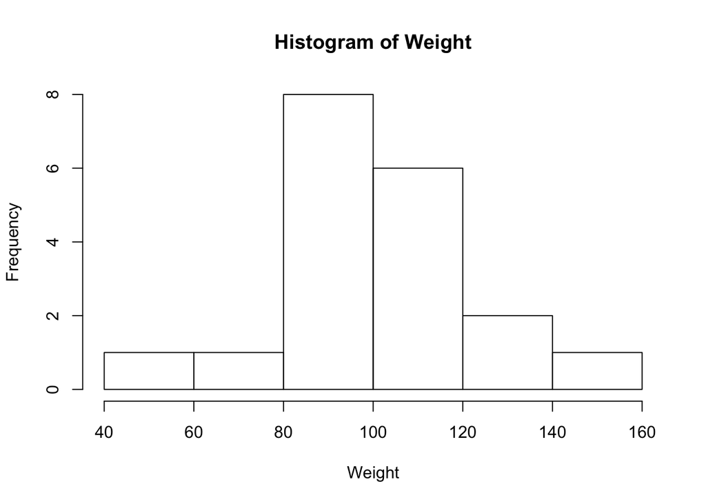

```r
# Setting student$Weight to a new variable “Weight” cleans up the labeling of
# the histogram
Weight <- student$Weight
hist(Weight)
```

[hist()](https://www.rdocumentation.org/packages/graphics/versions/3.4.0/topics/hist)

## 2.2 Visualize a single continuous variable by producing a boxplot.

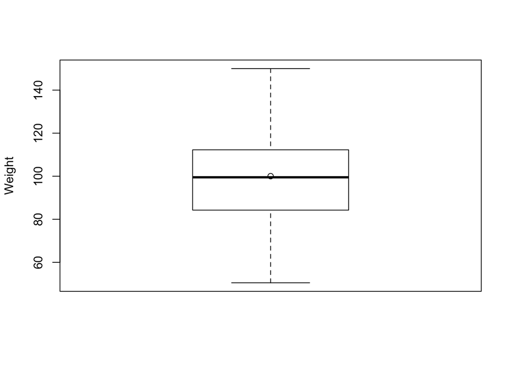

```r
# points(mean(Weight)) tells R to plot the mean on the boxplot
boxplot(Weight, ylab="Weight")
points(mean(Weight))
```

[boxplot()](https://www.rdocumentation.org/packages/graphics/versions/3.4.0/topics/boxplot) | [points()](https://www.rdocumentation.org/packages/graphics/versions/3.4.0/topics/points)

## 2.3 Visualize two continuous variables by producing a scatterplot.

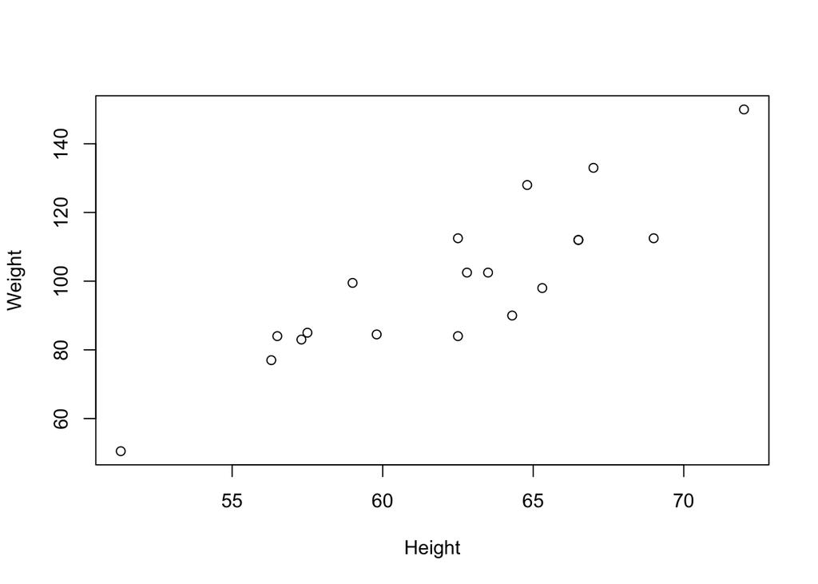

```r
Height <- student$Height
# Notice here you specify the x variable, followed by the y variable
plot(Height, Weight)
```

[plot()](https://www.rdocumentation.org/packages/graphics/versions/3.4.0/topics/plot)

## 2.4 Visualize a relationship between two continuous variables by producing a scatterplot and a plotted line of best fit.

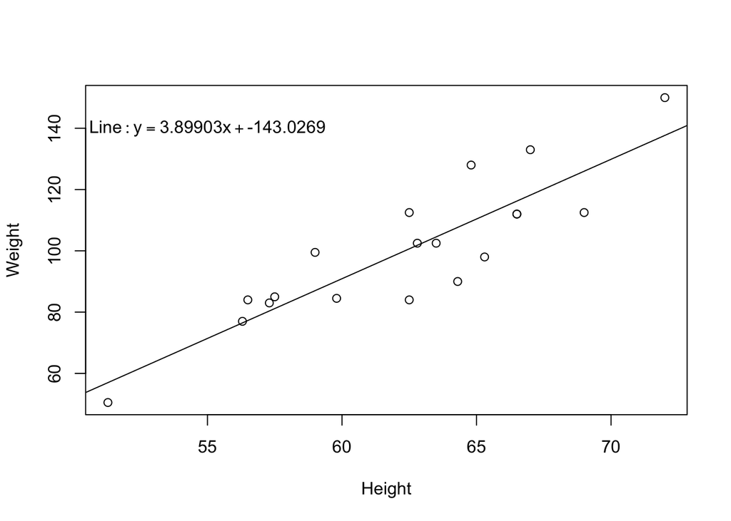

```r
plot(Height, Weight)

# lm() models Weight as a function of Height and returns the parameters
# of the line of best fit
model <- lm(Weight~Height)
coeff <- coef(model)
intercept <- as.matrix(coeff[1])[1]
slope <- as.matrix(coeff[2])[1]

# abline() prints the line of best fit
abline(lm(Weight~Height))

# text() prints the equation of the line of best fit, with the first
# two arguments specifying the x and y location, respectively, of where
# the text should be printed on the graph
text(55, 140, bquote(Line: y == .(slope) * x + .(intercept)))
```

[lm()](https://www.rdocumentation.org/packages/stats/versions/3.4.0/topics/lm) | [coef()](https://www.rdocumentation.org/packages/stats/versions/3.4.0/topics/coef) | [as.matrix()](https://www.rdocumentation.org/packages/base/versions/3.4.0/topics/matrix) | [abline()](https://www.rdocumentation.org/packages/graphics/versions/3.4.0/topics/abline) | [text()](https://www.rdocumentation.org/packages/graphics/versions/3.4.0/topics/text) | [bquote()](https://www.rdocumentation.org/packages/base/versions/3.4.0/topics/bquote)

## 2.5 Visualize a categorical variable by producing a bar chart.

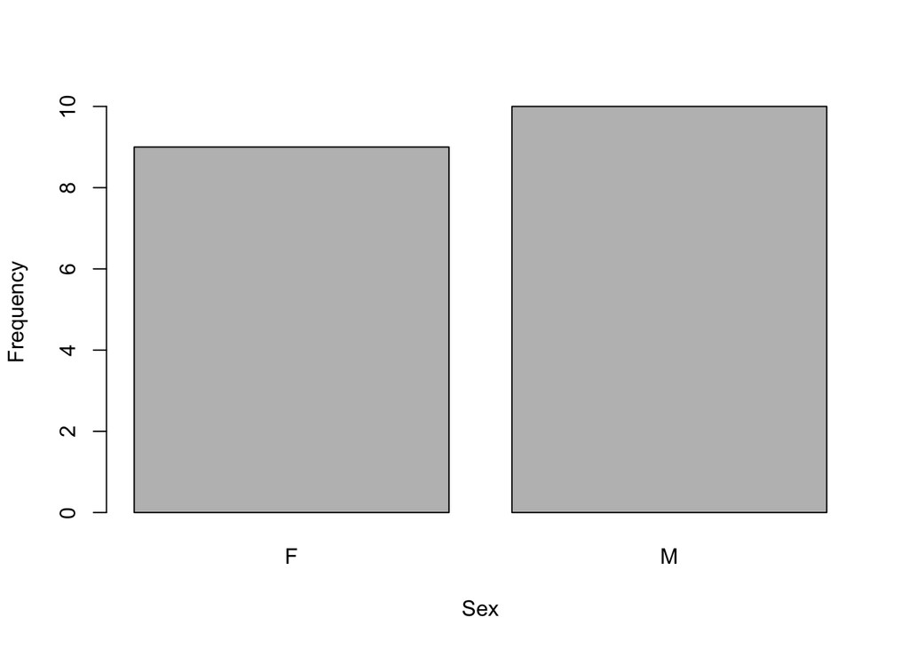

```r
counts <- table(student$Sex)

# beside = TRUE indicates to print the bars side by side instead of on top of
# each other
# names.arg indicates which names to use to label the bars
barplot(counts, beside=TRUE, ylab= "Frequency", xlab= "Sex",
        names.arg=names(counts))
```

[barplot()](https://www.rdocumentation.org/packages/graphics/versions/3.4.0/topics/barplot) | [names()](https://www.rdocumentation.org/packages/base/versions/3.4.0/topics/names)

## 2.6 Visualize a continuous variable, grouped by a categorical variable, using side-by-side boxplots.

### a) Simple side-by-side boxplot without color.

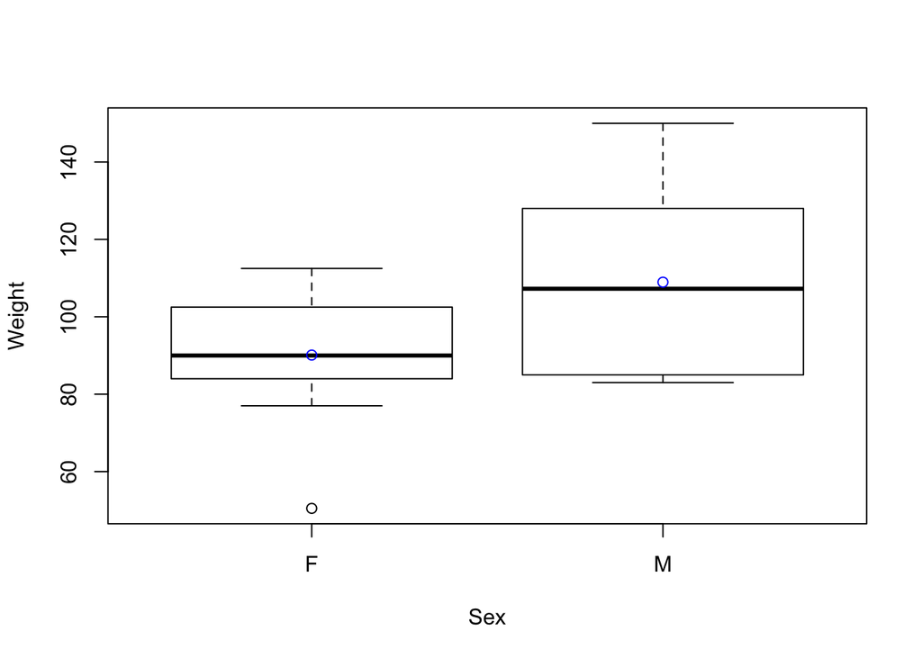

```r
# Subset data set to return only female weights, and then only male weights
Female_Weight <- student[which(student$Sex == 'F'), "Weight"]
Male_Weight <- student[which(student$Sex == 'M'), "Weight"]

# Find the mean of both arrays
means <- c(mean(Female_Weight), mean(Male_Weight))

# Syntax indicates Weight as a function of Sex
boxplot(student$Weight ~ student$Sex, ylab= "Weight", xlab= "Sex")

# Plot means on boxplots in blue
points(means, col= "blue")
```

### b) More advanced side-by-side boxplot with color.

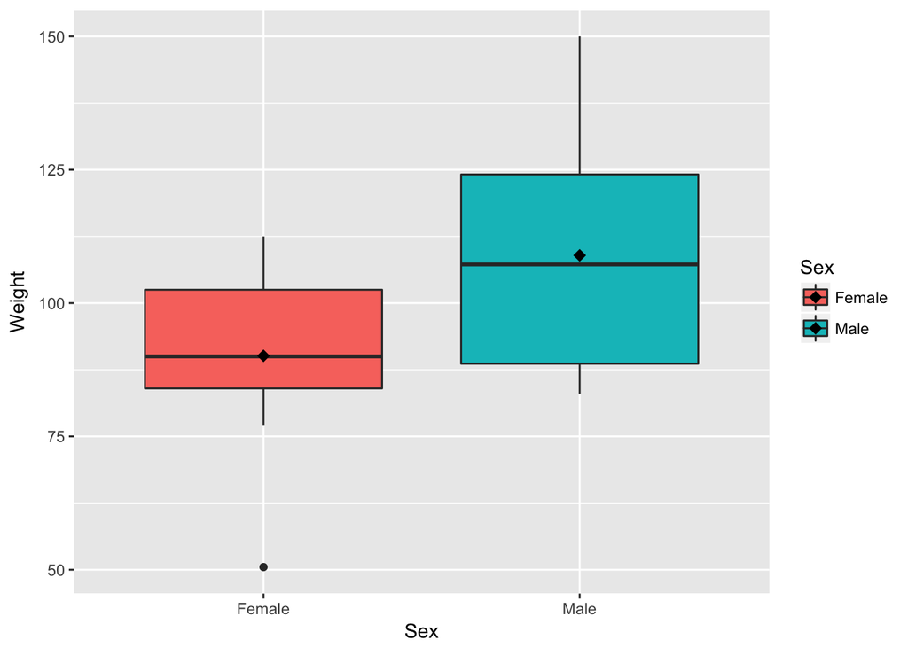

```r
# call the ggplot2 package
library(ggplot2)

student$Sex <- factor(student$Sex, levels = c("F","M"),
                      labels = c("Female", "Male"))
ggplot(data = student, aes(x = Sex, y = Weight, fill = Sex)) +
  geom_boxplot() + stat_summary(fun.y = mean,
                                color = "black", geom = "point",
                                shape = 18, size = 3)
```

ggplot2 | [factor()](https://www.rdocumentation.org/packages/base/versions/3.4.0/topics/factor) | [c()](https://www.rdocumentation.org/packages/base/versions/3.4.0/topics/c) | [aes()](https://www.rdocumentation.org/packages/ggplot2/versions/2.2.1/topics/aes) | [geom_boxplot()](https://www.rdocumentation.org/packages/ggplot2/versions/2.2.1/topics/geom_boxplot) | [stat_summary()](https://www.rdocumentation.org/packages/ggplot2/versions/2.2.1/topics/stat_summary_bin)

# 3 Basic Data Wrangling and Manipulation

## 3.1 Create a new variable in a data set as a function of existing variables in the data set.

```r
# Notice here how you can create the BMI column in the data set just by
# naming it
student$BMI <- student$Weight / (student$Height)**2 * 703
head(student, n=5)
```

| Name | Sex | Age | Height | Weight | BMI |
| --- | --- | --- | --- | --- | --- |
| Alfred | Male | 14 | 69.0 | 112.5 | 16.61153 |
| Alice | Female | 13 | 56.5 | 84.0 | 18.49855 |
| Barbara | Female | 13 | 65.3 | 98.0 | 16.15679 |
| Carol | Female | 14 | 62.8 | 102.5 | 18.27090 |
| Henry | Male | 14 | 63.5 | 102.5 | 17.87030 |

## 3.2 Create a new variable in a data set using if/else logic of existing variables in the data set.

```r
# Notice the use of the ifelse() function for a single condition
student$BMI_Class <- ifelse(student$BMI<19.0, "Underweight", "Healthy")
head(student, n=5)
```

| Name | Sex | Age | Height | Weight | BMI | BMI_Class |
| --- | --- | --- | --- | --- | --- | --- |
| Alfred | Male | 14 | 69.0 | 112.5 | 16.61153 | Underweight |
| Alice | Female | 13 | 56.5 | 84.0 | 18.49855 | Underweight |
| Barbara | Female | 13 | 65.3 | 98.0 | 16.15679 | Underweight |
| Carol | Female | 14 | 62.8 | 102.5 | 18.27090 | Underweight |
| Henry | Male | 14 | 63.5 | 102.5 | 17.87030 | Underweight |

[ifelse()](https://www.rdocumentation.org/packages/base/versions/3.4.0/topics/ifelse)

## 3.3 Create a new variable in a data set using mathemtical functions applied to existing variables in the data set.

Using the [log()](https://www.rdocumentation.org/packages/base/versions/3.4.0/topics/log), [exp()](https://www.rdocumentation.org/packages/base/versions/3.4.0/topics/log), [sqrt()](https://www.rdocumentation.org/packages/base/versions/3.4.0/topics/MathFun), [ifelse()](https://www.rdocumentation.org/packages/base/versions/3.4.0/topics/ifelse) and [abs()](https://www.rdocumentation.org/packages/base/versions/3.4.0/topics/MathFun) functions.

```r
student$LogWeight <- log(student$Weight)
student$ExpAge <- exp(student$Age)
student$SqrtHeight <- sqrt(student$Height)
student$BMI_Neg <- ifelse(student$BMI < 19.0, -student$BMI, student$BMI)
student$BMI_Pos <- abs(student$BMI_Neg)

# Create a Boolean variable
student$BMI_Check <- (student$BMI == student$BMI_Pos)
head(student, n=5)
```

| Name | Sex | Age | Height | Weight | BMI | BMI_Class | LogWeight | ExpAge | SqrtHeight | BMI_Neg | BMI_Pos | BMI_Check |
| --- | --- | --- | --- | --- | --- | --- | --- | --- | --- | --- | --- | --- |
| Alfred | Male | 14 | 69.0 | 112.5 | 16.61153 | Underweight | 4.722953 | 1202604.3 | 8.306624 | -16.61153 | 16.61153 | TRUE |
| Alice | Female | 13 | 56.5 | 84.0 | 18.49855 | Underweight | 4.430817 | 442413.4 | 7.516648 | -18.49855 | 18.49855 | TRUE |
| Barbara | Female | 13 | 65.3 | 98.0 | 16.15679 | Underweight | 4.584967 | 442413.4 | 8.080842 | -16.15679 | 16.15679 | TRUE |
| Carol | Female | 14 | 62.8 | 102.5 | 18.27090 | Underweight | 4.629863 | 1202604.3 | 7.924645 | -18.27090 | 18.27090 | TRUE |
| Henry | Male | 14 | 63.5 | 102.5 | 17.87030 | Underweight | 4.629863 | 1202604.3 | 7.968689 | -17.87030 | 17.87030 | TRUE |

## 3.4 Drop variables from a data set.

```r
# -c() function tells R not to select the columns listed
student <- subset(student, select = -c(LogWeight, ExpAge, SqrtHeight,
                                       BMI_Neg, BMI_Pos, BMI_Check))
head(student, n=5)
```

| Name | Sex | Age | Height | Weight | BMI | BMI_Class |
| --- | --- | --- | --- | --- | --- | --- |
| Alfred | Male | 14 | 69.0 | 112.5 | 16.61153 | Underweight |
| Alice | Female | 13 | 56.5 | 84.0 | 18.49855 | Underweight |
| Barbara | Female | 13 | 65.3 | 98.0 | 16.15679 | Underweight |
| Carol | Female | 14 | 62.8 | 102.5 | 18.27090 | Underweight |
| Henry | Male | 14 | 63.5 | 102.5 | 17.87030 | Underweight |

## 3.5 Sort a data set by a variable.

### a) Sort data set by a continuous variable.

```r
student <- student[order(student$Age), ]
# Notice that R uses a stable sorting algorithm by default
head(student, n=5)
```

| Name | Sex | Age | Height | Weight | BMI | BMI_Class |
| --- | --- | --- | --- | --- | --- | --- |
| Joyce | Female | 11 | 51.3 | 50.5 | 13.49000 | Underweight |
| Thomas | Male | 11 | 57.5 | 85.0 | 18.07335 | Underweight |
| James | Male | 12 | 57.3 | 83.0 | 17.77150 | Underweight |
| Jane | Female | 12 | 59.8 | 84.5 | 16.61153 | Underweight |
| John | Male | 12 | 59.0 | 99.5 | 20.09437 | Healthy |

### b) Sort data set by a categorical variable.

```r
student <- student[order(student$Sex), ]
# Notice that the data is now sorted first by Sex and then within Sex by Age
head(student, n=5)
```

| Name | Sex | Age | Height | Weight | BMI | BMI_Class |
| --- | --- | --- | --- | --- | --- | --- |
| Joyce | Female | 11 | 51.3 | 50.5 | 13.49000 | Underweight |
| Jane | Female | 12 | 59.8 | 84.5 | 16.61153 | Underweight |
| Louise | Female | 12 | 56.3 | 77.0 | 17.07770 | Underweight |
| Alice | Female | 13 | 56.5 | 84.0 | 18.49855 | Underweight |
| Barbara | Female | 13 | 65.3 | 98.0 | 16.15679 | Underweight |

[order()](https://www.rdocumentation.org/packages/base/versions/3.4.0/topics/order)

## 3.6 Compute descriptive statistics of continuous variables, grouped by a categorical variable.

```r
# Notice the syntax of Age, Height, Weight, and BMI as a function of Sex
aggregate(cbind(Age, Height, Weight, BMI) ~ Sex, student, mean)
```

| Sex | Age | Height | Weight | BMI |
| --- | --- | --- | --- | --- |
| Female | 13.22222 | 60.58889 | 90.11111 | 17.05104 |
| Male | 13.40000 | 63.91000 | 108.95000 | 18.59424 |

[aggregate()](https://www.rdocumentation.org/packages/stats/versions/3.4.0/topics/aggregate) | [cbind()](https://www.rdocumentation.org/packages/base/versions/3.4.0/topics/cbind)

## 3.7 Add a new row to the bottom of a data set.

```r
# Look at the tail of the data currently
tail(student, n=5)
```

| Name | Sex | Age | Height | Weight | BMI | BMI_Class |
| --- | --- | --- | --- | --- | --- | --- |
| Alfred | Male | 14 | 69.0 | 112.5 | 16.61153 | Underweight |
| Henry | Male | 14 | 63.5 | 102.5 | 17.87030 | Underweight |
| Ronald | Male | 15 | 67.0 | 133.0 | 20.82847 | Healthy |
| William | Male | 15 | 66.5 | 112.0 | 17.80451 | Underweight |
| Philip | Male | 16 | 72.0 | 150.0 | 20.34144 | Healthy |

```r
# rbind.data.frame() function binds two data frames together by rows
student <- rbind.data.frame(student, data.frame(Name='Jane', Sex = 'F',
                                                Age = 14, Height = 56.3,
                                                Weight = 77.0,
                                                BMI = 17.077695,
                                                BMI_Class = 'Underweight'))
tail(student, n=5)
```

| Name | Sex | Age | Height | Weight | BMI | BMI_Class |
| --- | --- | --- | --- | --- | --- | --- |
| Henry | Male | 14 | 63.5 | 102.5 | 17.87030 | Underweight |
| Ronald | Male | 15 | 67.0 | 133.0 | 20.82847 | Healthy |
| William | Male | 15 | 66.5 | 112.0 | 17.80451 | Underweight |
| Philip | Male | 16 | 72.0 | 150.0 | 20.34144 | Healthy |
| Jane | F | 14 | 56.3 | 77.0 | 17.07769 | Underweight |

[data.frame()](https://www.rdocumentation.org/packages/base/versions/3.4.0/topics/data.frame) | [rbind.data.frame()](https://www.rdocumentation.org/packages/base/versions/3.4.0/topics/cbind)

## 3.8 Create a user-defined function and apply it to a variable in the data set to create a new variable in the data set.

```r
toKG <- function(lb) {
  return(0.45359237 * lb)
}

student$Weight_KG <- toKG(student$Weight)
head(student, n=5)
```

| Name | Sex | Age | Height | Weight | BMI | BMI_Class | Weight_KG |
| --- | --- | --- | --- | --- | --- | --- | --- |
| Joyce | Female | 11 | 51.3 | 50.5 | 13.49000 | Underweight | 22.90641 |
| Jane | Female | 12 | 59.8 | 84.5 | 16.61153 | Underweight | 38.32856 |
| Louise | Female | 12 | 56.3 | 77.0 | 17.07770 | Underweight | 34.92661 |
| Alice | Female | 13 | 56.5 | 84.0 | 18.49855 | Underweight | 38.10176 |
| Barbara | Female | 13 | 65.3 | 98.0 | 16.15679 | Underweight | 44.45205 |

[user-defined functions](http://www.statmethods.net/management/userfunctions.html)

# 4 More Advanced Data Wrangling

## 4.1 Drop observations with missing information.

```r
# Notice the use of the fish data set because it has some missing
# observations
fish <- read.csv('/Users/fish.csv')

# First sort by Weight, requesting those with NA for Weight first
fish <- fish[order(fish$Weight, na.last=FALSE), ]
head(fish, n=5)
```

| Species | Weight | Length1 | Length2 | Length3 | Height | Width |
| --- | --- | --- | --- | --- | --- | --- |
| Bream | NA | 29.5 | 32.0 | 37.3 | 13.9129 | 5.0728 |
| Roach | 0.0 | 19.0 | 20.5 | 22.8 | 6.4752 | 3.3516 |
| Perch | 5.9 | 7.5 | 8.4 | 8.8 | 2.1120 | 1.4080 |
| Smelt | 6.7 | 9.3 | 9.8 | 10.8 | 1.7388 | 1.0476 |
| Smelt | 7.0 | 10.1 | 10.6 | 11.6 | 1.7284 | 1.1484 |

–

```r
new_fish <- na.omit(fish)
head(new_fish, n=5)
```

| Species | Weight | Length1 | Length2 | Length3 | Height | Width |
| --- | --- | --- | --- | --- | --- | --- |
| Roach | 0.0 | 19.0 | 20.5 | 22.8 | 6.4752 | 3.3516 |
| Perch | 5.9 | 7.5 | 8.4 | 8.8 | 2.1120 | 1.4080 |
| Smelt | 6.7 | 9.3 | 9.8 | 10.8 | 1.7388 | 1.0476 |
| Smelt | 7.0 | 10.1 | 10.6 | 11.6 | 1.7284 | 1.1484 |
| Smelt | 7.5 | 10.0 | 10.5 | 11.6 | 1.9720 | 1.1600 |

[na.omit()](https://www.rdocumentation.org/packages/data.table/versions/1.10.4/topics/na.omit.data.table)

## 4.2 Merge two data sets together on a common variable.

### a) First, select specific columns of a data set to create two smaller data sets.

```r
# Notice the use of the student data set again, however we want to reload
# it without the changes we've made previously
student <- read.csv('/Users/class.csv')
student1 <- subset(student, select=c(Name, Sex, Age))
head(student1, n=5)
```

| Name | Sex | Age |
| --- | --- | --- |
| Alfred | M | 14 |
| Alice | F | 13 |
| Barbara | F | 13 |
| Carol | F | 14 |
| Henry | M | 14 |

–

```r
student2 <- subset(student, select=c(Name, Height, Weight))
head(student2, n=5)
```

| Name | Height | Weight |
| --- | --- | --- |
| Alfred | 69.0 | 112.5 |
| Alice | 56.5 | 84.0 |
| Barbara | 65.3 | 98.0 |
| Carol | 62.8 | 102.5 |
| Henry | 63.5 | 102.5 |

### b) Second, we want to merge the two smaller data sets on the common variable.

```r
new <- merge(student1, student2)
head(new, n=5)
```

| Name | Sex | Age | Height | Weight |
| --- | --- | --- | --- | --- |
| Alfred | M | 14 | 69.0 | 112.5 |
| Alice | F | 13 | 56.5 | 84.0 |
| Barbara | F | 13 | 65.3 | 98.0 |
| Carol | F | 14 | 62.8 | 102.5 |
| Henry | M | 14 | 63.5 | 102.5 |

[merge()](https://www.rdocumentation.org/packages/base/versions/3.4.0/topics/merge)

### c) Finally, we want to check to see if the merged data set is the same as the original data set.

```r
all.equal(student, new)
```

```
## [1] TRUE
```

[all.equal()](https://www.rdocumentation.org/packages/data.table/versions/1.10.4/topics/all.equal)

## 4.3 Merge two data sets together by index number only.

### a) First, select specific columns of a data set to create two smaller data sets.

```r
newstudent1 <- subset(student, select=c(Name, Sex, Age))
head(newstudent1, n=5)
```

| Name | Sex | Age |
| --- | --- | --- |
| Alfred | M | 14 |
| Alice | F | 13 |
| Barbara | F | 13 |
| Carol | F | 14 |
| Henry | M | 14 |

–

```r
newstudent2 <- subset(student, select=c(Height, Weight))
head(newstudent2, n=5)
```

| Height | Weight |
| --- | --- |
| 69.0 | 112.5 |
| 56.5 | 84.0 |
| 65.3 | 98.0 |
| 62.8 | 102.5 |
| 63.5 | 102.5 |

### b) Second, we want to join the two smaller data sets.

```r
new2 <- cbind(newstudent1, newstudent2)
head(new2, n=5)
```

| Name | Sex | Age | Height | Weight |
| --- | --- | --- | --- | --- |
| Alfred | M | 14 | 69.0 | 112.5 |
| Alice | F | 13 | 56.5 | 84.0 |
| Barbara | F | 13 | 65.3 | 98.0 |
| Carol | F | 14 | 62.8 | 102.5 |
| Henry | M | 14 | 63.5 | 102.5 |

### c) Finally, we want to check to see if the joined data set is the same as the original data set.

```r
all.equal(student, new2)
```

```
## [1] TRUE
```

## 4.4 Create a pivot table to summarize information about a data set.

```r
# Notice we are using a new data set that needs to be read into the
# environment
price <- read.csv('/Users/price.csv')

# call the dplyr package
library(dplyr)

# The following code is used to remove the "," and "$" characters from the
# ACTUAL column so that values can be summed
price$ACTUAL <- gsub('[$]', '', price$ACTUAL)
price$ACTUAL <- as.numeric(gsub(',', '', price$ACTUAL))

filtered <- group_by(price, COUNTRY, STATE, PRODTYPE, PRODUCT)
basic_sum <- summarise(filtered, REVENUE = sum(ACTUAL))
head(basic_sum, n=5)
```

| COUNTRY | STATE | PRODTYPE | PRODUCT | REVENUE |
| --- | --- | --- | --- | --- |
| Canada | British Columbia | FURNITURE | BED | 197706.6 |
| Canada | British Columbia | FURNITURE | SOFA | 216282.6 |
| Canada | British Columbia | OFFICE | CHAIR | 200905.2 |
| Canada | British Columbia | OFFICE | DESK | 186262.2 |
| Canada | Ontario | FURNITURE | BED | 194493.6 |

dplyr | group_by | [summarise()](https://www.rdocumentation.org/packages/dplyr/versions/0.5.0/topics/summarise)

## 4.5 Return all unique values from a text variable.

```r
print(unique(price$STATE))
```

```
##  [1] California            Colorado              Florida
##  [4] Illinois              New York              North Carolina
##  [7] Texas                 Washington            Baja California Norte
## [10] Campeche              Michoacan             Nuevo Leon
## [13] British Columbia      Ontario               Quebec
## [16] Saskatchewan
## 16 Levels: Baja California Norte British Columbia California ... Washington
```

[unique()](https://www.rdocumentation.org/packages/base/versions/3.4.0/topics/unique)

In the following sections, several data set will be used more than once for prediction and modeling. Often, they will be re-read into the environment so we are always going back to the original, raw data.

# 5 Preparation & Basic Regression

## 5.1 Pre-process a data set using principal component analysis.

```r
# Notice we are using a new data set that needs to be read into the
# environment
iris <- read.csv('/Users/iris.csv')
features <- subset(iris, select = -c(Target))

pca <- prcomp(x = features, scale = TRUE)
print(pca)
```

```
## Standard deviations:
## [1] 1.7061120 0.9598025 0.3838662 0.1435538
##
## Rotation:
##                    PC1         PC2        PC3        PC4
## SepalLength  0.5223716 -0.37231836  0.7210168  0.2619956
## SepalWidth  -0.2633549 -0.92555649 -0.2420329 -0.1241348
## PetalLength  0.5812540 -0.02109478 -0.1408923 -0.8011543
## PetalWidth   0.5656110 -0.06541577 -0.6338014  0.5235463
```

[prcomp()](https://stat.ethz.ch/R-manual/R-devel/library/stats/html/prcomp.html)

## 5.2 Split data into training and testing data and export as a .csv file.

```r
# Set the sample size of the training data
smp_size <- floor(0.7 * nrow(iris))

# set.seed() is used to specify a seed for a random integer so that the
# results are reproducible
set.seed(29)
train_ind <- sample(seq_len(nrow(iris)), size = smp_size)

train <- iris[train_ind, ]
test <- iris[-train_ind, ]

write.csv(train, file = "/Users/iris_train_R.csv")
write.csv(test, file = "/Users/iris_test_R.csv")
```

[floor()](https://www.rdocumentation.org/packages/base/versions/3.4.0/topics/Round) | [nrow()](https://www.rdocumentation.org/packages/base/versions/3.4.0/topics/nrow) | [set.seed()](https://www.rdocumentation.org/packages/base/versions/3.4.0/topics/Random) | [sample()](https://www.rdocumentation.org/packages/base/versions/3.4.0/topics/sample) | [seq_len()](https://www.rdocumentation.org/packages/base/versions/3.4.0/topics/seq) | [write.csv()](https://www.rdocumentation.org/packages/utils/versions/3.4.0/topics/write.table)

## 5.3 Fit a logistic regression model.

```r
# Notice we are using a new data set that needs to be read into the
# environment
tips <- read.csv('/Users/tips.csv')

# The following code is used to determine if the individual left more
# than a 15% tip
tips$fifteen <- 0.15 * tips$total_bill
tips$greater15 <- ifelse(tips$tip > tips$fifteen, 1, 0)

# Notice the syntax of greater15 as a function of total_bill
# You could fit the model of greater15 as a function of all
# other variables with "greater15 ~ ."
logreg <- glm(greater15 ~ total_bill, data = tips,
              family = "binomial"(link='logit'))
summary(logreg)
```

```
##
## Call:
## glm(formula = greater15 ~ total_bill, family = binomial(link = "logit"),
##     data = tips)
##
## Deviance Residuals:
##     Min       1Q   Median       3Q      Max
## -1.6757  -1.1766   0.8145   1.0145   2.0774
##
## Coefficients:
##             Estimate Std. Error z value Pr(>|z|)
## (Intercept)  1.64772    0.35467   4.646 3.39e-06 ***
## total_bill  -0.07248    0.01678  -4.319 1.57e-05 ***
## ---
## Signif. codes:  0 '***' 0.001 '**' 0.01 '*' 0.05 '.' 0.1 ' ' 1
##
## (Dispersion parameter for binomial family taken to be 1)
##
##     Null deviance: 335.48  on 243  degrees of freedom
## Residual deviance: 313.74  on 242  degrees of freedom
## AIC: 317.74
##
## Number of Fisher Scoring iterations: 4
```

[glm()](https://www.rdocumentation.org/packages/stats/versions/3.4.0/topics/glm)

## 5.4 Fit a linear regression model.

```r
# Notice the syntax of tip as function of total_bill
linreg <- lm(tip ~ total_bill, data = tips)
summary(linreg)
```

```
##
## Call:
## lm(formula = tip ~ total_bill, data = tips)
##
## Residuals:
##     Min      1Q  Median      3Q     Max
## -3.1982 -0.5652 -0.0974  0.4863  3.7434
##
## Coefficients:
##             Estimate Std. Error t value Pr(>|t|)
## (Intercept) 0.920270   0.159735   5.761 2.53e-08 ***
## total_bill  0.105025   0.007365  14.260  < 2e-16 ***
## ---
## Signif. codes:  0 '***' 0.001 '**' 0.01 '*' 0.05 '.' 0.1 ' ' 1
##
## Residual standard error: 1.022 on 242 degrees of freedom
## Multiple R-squared:  0.4566, Adjusted R-squared:  0.4544
## F-statistic: 203.4 on 1 and 242 DF,  p-value: < 2.2e-16
```

[lm()](https://www.rdocumentation.org/packages/stats/versions/3.4.0/topics/lm)

# 6 Supervised Machine Learning

Many of the following models will make use of the [predict()](https://www.rdocumentation.org/packages/stats/versions/3.4.0/topics/predict) function.

## 6.1 Fit a logistic regression model on training data and assess against testing data.

### a) Fit a logistic regression model on training data.

```r
# Notice we are using new data sets that need to be read into the environment
train <- read.csv('/Users/tips_train.csv')
test <- read.csv('/Users/tips_test.csv')

train$fifteen <- 0.15 * train$total_bill
train$greater15 <- ifelse(train$tip > train$fifteen, 1, 0)
test$fifteen <- 0.15 * test$total_bill
test$greater15 <- ifelse(test$tip > test$fifteen, 1, 0)

logreg <- glm(greater15 ~ total_bill, data = train,
              family = "binomial"(link='logit'))
summary(logreg)
```

```
##
## Call:
## glm(formula = greater15 ~ total_bill, family = binomial(link = "logit"),
##     data = train)
##
## Deviance Residuals:
##     Min       1Q   Median       3Q      Max
## -1.6409  -1.1929   0.8144   1.0027   2.0381
##
## Coefficients:
##             Estimate Std. Error z value Pr(>|z|)
## (Intercept)  1.64613    0.39459   4.172 3.02e-05 ***
## total_bill  -0.07064    0.01849  -3.820 0.000134 ***
## ---
## Signif. codes:  0 '***' 0.001 '**' 0.01 '*' 0.05 '.' 0.1 ' ' 1
##
## (Dispersion parameter for binomial family taken to be 1)
##
##     Null deviance: 267.61  on 194  degrees of freedom
## Residual deviance: 250.58  on 193  degrees of freedom
## AIC: 254.58
##
## Number of Fisher Scoring iterations: 4
```

### b) Assess the model against the testing data.

```r
# Prediction on testing data
predictions <- predict(logreg, test, type = 'response')
predY <- ifelse(predictions < 0.5, 0, 1)

# If the prediction probability is less than 0.5, classify this as a 0
# and otherwise classify as a 1.  This isn't the best method -- a better
# method would be randomly assigning a 0 or 1 when a probability of 0.5
# occurrs, but this insures that results are consistent

# Determine how many were correctly classified
Results <- ifelse(predY == test$greater15, "Correct", "Wrong")
table(Results)
```

```
## Results
## Correct   Wrong
##      34      15
```

[glm()](https://www.rdocumentation.org/packages/stats/versions/3.4.0/topics/glm)

## 6.2 Fit a linear regression model on training data and assess against testing data.

### a) Fit a linear regression model on training data.

```r
# Notice we are using new data sets that need to be read into the environment
train <- read.csv('/Users/boston_train.csv')
test <- read.csv('/Users/boston_test.csv')

# Fit a linear regression model
# The "." character tells the model to use all variables except the response
# variabe (Target)
linreg <- lm(Target ~ ., data = train)
summary(linreg)
```

```
##
## Call:
## lm(formula = Target ~ ., data = train)
##
## Residuals:
##      Min       1Q   Median       3Q      Max
## -15.6466  -2.8461  -0.5395   1.7077  26.2160
##
## Coefficients:
##               Estimate Std. Error t value Pr(>|t|)
## (Intercept)  36.108196   6.504968   5.551 5.73e-08 ***
## X0           -0.085634   0.042774  -2.002 0.046077 *
## X1            0.046034   0.017150   2.684 0.007626 **
## X2            0.036413   0.076006   0.479 0.632186
## X3            3.247961   1.074138   3.024 0.002686 **
## X4          -14.872938   4.636090  -3.208 0.001463 **
## X5            3.576869   0.536993   6.661 1.10e-10 ***
## X6           -0.008703   0.016853  -0.516 0.605890
## X7           -1.368905   0.252960  -5.412 1.18e-07 ***
## X8            0.313120   0.082366   3.802 0.000170 ***
## X9           -0.012882   0.004599  -2.801 0.005383 **
## X10          -0.976900   0.170996  -5.713 2.43e-08 ***
## X11           0.011326   0.003359   3.372 0.000832 ***
## X12          -0.526715   0.062563  -8.419 1.08e-15 ***
## ---
## Signif. codes:  0 '***' 0.001 '**' 0.01 '*' 0.05 '.' 0.1 ' ' 1
##
## Residual standard error: 4.988 on 340 degrees of freedom
## Multiple R-squared:  0.7236, Adjusted R-squared:  0.7131
## F-statistic: 68.48 on 13 and 340 DF,  p-value: < 2.2e-16
```

### b) Assess the model against the testing data.

```r
# Predict on testing data
prediction <- data.frame(matrix(ncol = 0, nrow = nrow(test)))
prediction$predY <- predict(linreg, newdata = test)

# Compute the squared difference between predicted tip and actual tip
prediction$sq_diff <- (prediction$predY - test$Target)**2

# Compute the mean of the squared differences (mean squared error)
# as an assessment of the model
mean_sq_error <- mean(prediction$sq_diff)
print(mean_sq_error)
```

```
## [1] 17.77131
```

[lm()](https://www.rdocumentation.org/packages/stats/versions/3.4.0/topics/lm)

## 6.3 Fit a decision tree model on training data and assess against testing data.

### a) Fit a decision tree classification model.

#### i) Fit a decision tree classification model on training data and determine variable importance.

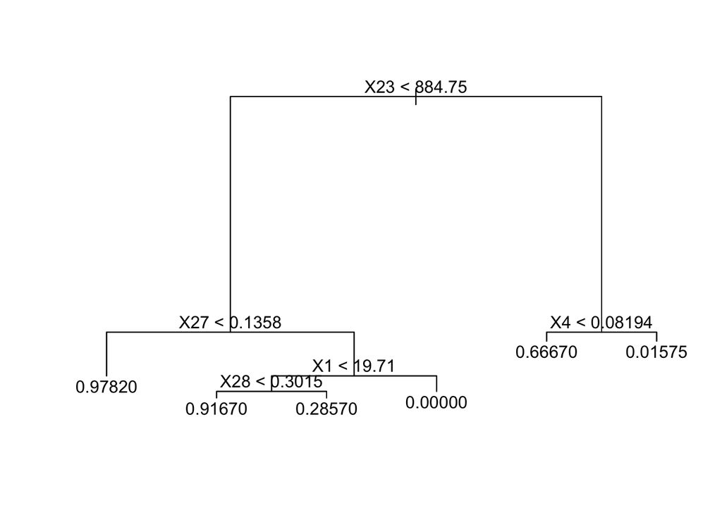

```r
# Notice we are using new data sets that need to be read into the environment
train <- read.csv('/Users/breastcancer_train.csv')
test <- read.csv('/Users/breastcancer_test.csv')

# call the tree package
library(tree)

treeMod <- tree(Target ~ ., data = train, method = "class")

# Plot the decision tree
plot(treeMod)
text(treeMod)
```

```r
# Determine variable importance
summary(treeMod)
```

```
##
## Regression tree:
## tree(formula = Target ~ ., data = train, method = "class")
## Variables actually used in tree construction:
## [1] "X23" "X27" "X1"  "X28" "X4"
## Number of terminal nodes:  6
## Residual mean deviance:  0.02688 = 10.54 / 392
## Distribution of residuals:
##     Min.  1st Qu.   Median     Mean  3rd Qu.     Max.
## -0.97820 -0.01575  0.02183  0.00000  0.02183  0.98430
```

#### ii) Assess the model against the testing data.

```r
# Prediction on testing data
out <- predict(treeMod, test)
out <- unname(out)
predY <- ifelse(out < 0.5, 0, 1)

# Determine how many were correctly classified
Results <- ifelse(test$Target == predY, "Correct", "Wrong")
table(Results)
```

```
## Results
## Correct   Wrong
##     159      12
```

tree

### b) Fit a decision tree regression model.

#### i) Fit a decision tree regression model on training data and determine variable importance.

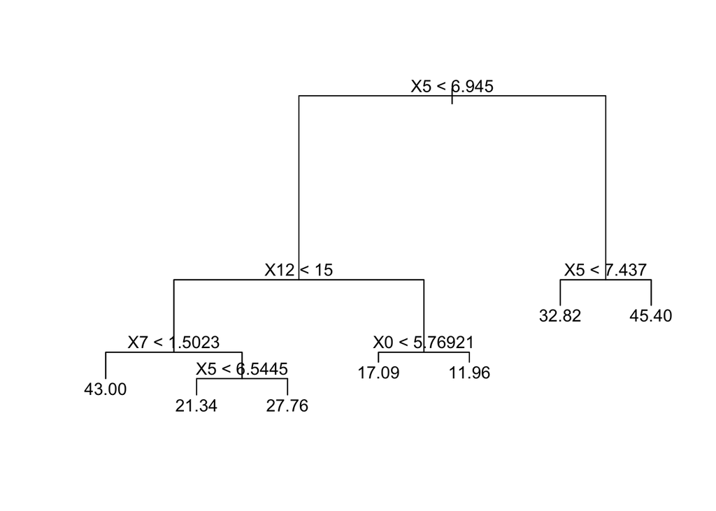

```r
train <- read.csv('/Users/boston_train.csv')
test <- read.csv('/Users/boston_test.csv')

treeMod <- tree(Target ~ ., data = train)

# Plot the decision tree
plot(treeMod)
text(treeMod)
```

```r
# Determine variable importance
summary(treeMod)
```

```
##
## Regression tree:
## tree(formula = Target ~ ., data = train)
## Variables actually used in tree construction:
## [1] "X5"  "X12" "X7"  "X0"
## Number of terminal nodes:  7
## Residual mean deviance:  14.67 = 5091 / 347
## Distribution of residuals:
##     Min.  1st Qu.   Median     Mean  3rd Qu.     Max.
## -28.0000  -1.8070   0.3264   0.0000   2.2320  10.0100
```

#### ii) Assess the model against the testing data.

```r
# Prediction on testing data
prediction <- data.frame(matrix(ncol = 0, nrow = nrow(test)))
prediction$predY <- predict(treeMod, newdata = test)

# Determine mean squared error
prediction$sq_diff <- (prediction$predY - test$Target)**2
mean_sq_error <- mean(prediction$sq_diff)
print(mean_sq_error)
```

```
## [1] 25.12126
```

tree

## 6.4 Fit a random forest model on training data and assess against testing data.

### a) Fit a random forest classification model.

#### i) Fit a random forest classification model on training data and determine variable importance.

```r
train <- read.csv('/Users/breastcancer_train.csv')
test <- read.csv('/Users/breastcancer_test.csv')

# call the randomForest package
library(randomForest)
set.seed(29)

# as.factor() since classification model
rfMod <- randomForest(as.factor(Target) ~ ., data = train)

# Determine variable importance
var_import <- importance(rfMod)
var_import <- data.frame(sort(var_import, decreasing = TRUE,
                              index.return = TRUE))
var_import$MeanDecreaseGini <- var_import$x
var_import$X <- var_import$ix - 1
var_import <- subset(var_import, select = -c(ix, x))
head(var_import, n=5)
```

| MeanDecreaseGini | X |
| --- | --- |
| 22.88452 | 27 |
| 21.64371 | 7 |
| 21.56885 | 22 |
| 20.13103 | 23 |
| 18.90989 | 20 |

#### ii) Assess the model against the testing data.

```r
# Prediction on testing data
predY <- predict(rfMod, test)

# Determine how many were correctly classified
Results <- ifelse(test$Target == predY, "Correct", "Wrong")
table(Results)
```

```
## Results
## Correct   Wrong
##     166       5
```

randomForest | [as.factor()](https://stat.ethz.ch/R-manual/R-devel/library/base/html/factor.html)

### b) Fit a random forest regression model.

#### i) Fit a random forest regression model on training data and determine variable importance.

```r
train <- read.csv('/Users/boston_train.csv')
test <- read.csv('/Users/boston_test.csv')

# call the randomForest package
library(randomForest)
set.seed(29)

rfMod <- randomForest(Target ~ ., data = train)

# Determine variable importance
var_import <- importance(rfMod)
var_import <- data.frame(sort(var_import, decreasing = TRUE,
                              index.return = TRUE))
var_import$MeanDecreaseGini <- var_import$x
var_import$X <- var_import$ix - 1
var_import <- subset(var_import, select = -c(ix, x))
head(var_import, n=5)
```

| MeanDecreaseGini | X |
| --- | --- |
| 8662.298 | 12 |
| 8451.836 | 5 |
| 2147.288 | 0 |
| 2105.072 | 7 |
| 1915.570 | 2 |

#### ii) Assess the model against the testing data.

```r
# Prediction on testing data
prediction <- data.frame(matrix(ncol = 0, nrow = nrow(test)))
prediction$predY <- predict(rfMod, newdata = test)

# Determine mean squared error
prediction$sq_diff <- (prediction$predY - test$Target)**2
mean_sq_error <- mean(prediction$sq_diff)
print(mean_sq_error)
```

```
## [1] 9.028163
```

randomForest

## 6.5 Fit a gradient boosting model on training data and assess against testing data.

### a) Fit a gradient boosting classification model.

#### i) Fit a gradient boosting classification model on training data and determine variable importance.

```r
train <- read.csv('/Users/breastcancer_train.csv')
test <- read.csv('/Users/breastcancer_test.csv')

# call the gbm package
library(gbm)
set.seed(29)

# distribution = "bernoulli" is appropriate when there are only 2
# unique values
# n.trees = total number of trees to fit which is analogous to the number
# of iterations
# shrinkage = learning rate or step-size reduction, whereas a lower
# learning rate requires more iterations
gbMod <- gbm(Target ~ ., distribution = "bernoulli", data = train,
             n.trees = 2500, shrinkage = .01)

# Determine variable importance
var_import <- summary(gbMod)
```

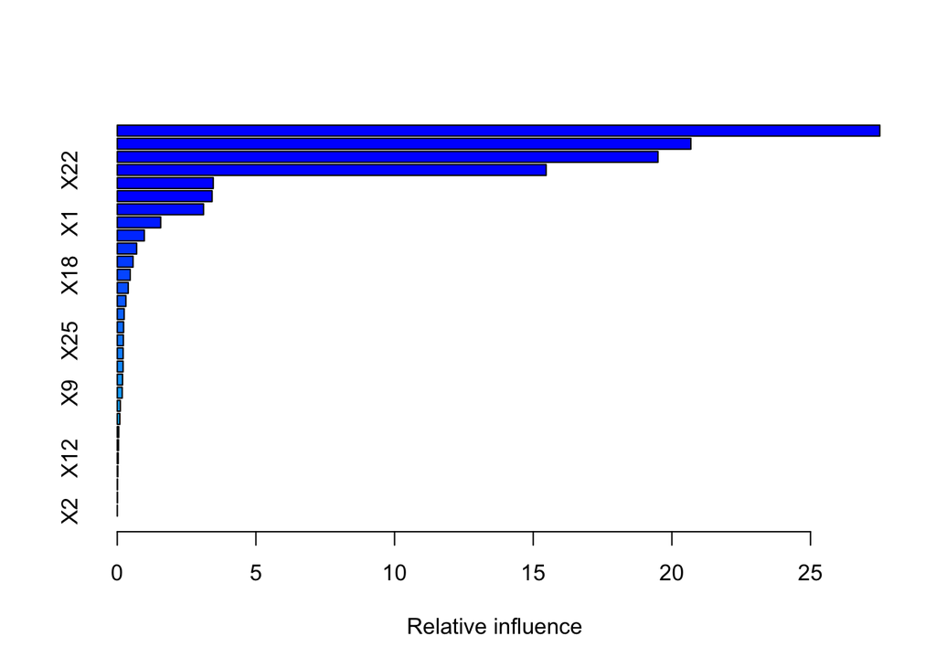

```r
head(var_import, n=5)
```

| var | rel.inf |
| --- | --- |
| X27 | 27.50103 |
| X7 | 20.68575 |
| X23 | 19.49976 |
| X22 | 15.46766 |
| X13 | 3.46162 |

#### ii) Assess the model against the testing data.

```r
# Prediction on testing data
out <- predict(object = gbMod, newdata = test,
                         type = "response", n.trees = 2500)
predY <- ifelse(out < 0.5, 0, 1)

# Determine how many were correctly classified
Results <- ifelse(test$Target == predY, "Correct", "Wrong")
table(Results)
```

```
## Results
## Correct   Wrong
##     167       4
```

gbm

### b) Fit a gradient boosting regression model.

#### i) Fit a gradient boosting regression model on training data and determine variable importance.

```r
train <- read.csv('/Users/boston_train.csv')
test <- read.csv('/Users/boston_test.csv')

# call the gbm package
library(gbm)
set.seed(29)

gbMod <- gbm(Target ~ ., data = train, distribution = "gaussian",
             n.trees = 2500, shrinkage = .01)

# Determine variable importance
var_import <- summary(gbMod)
```

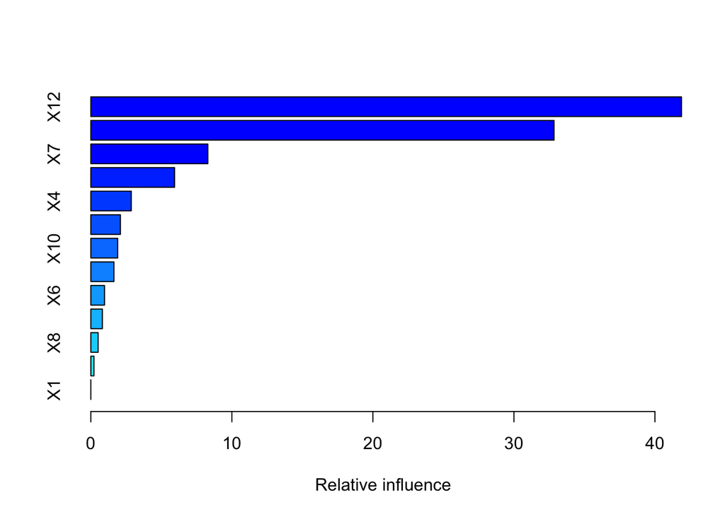

```r
head(var_import, n=5)
```

| var | rel.inf |
| --- | --- |
| X12 | 41.882259 |
| X5 | 32.846422 |
| X7 | 8.298140 |
| X0 | 5.937391 |
| X4 | 2.867877 |

#### ii) Assess the model against the testing data.

```r
# Predict the Target in the testing data, remembeing to multiply by 50
prediction <- data.frame(matrix(ncol = 0, nrow = nrow(test)))
prediction$predY <- predict(object = gbMod, newdata = test,
                            type = "response", n.trees = 2500)

# Compute mean squared error
prediction$sq_diff <- (prediction$predY - test$Target)**2
mean_sq_error <- mean(prediction$sq_diff)
print(mean_sq_error)
```

```
## [1] 11.88728
```

gbm

## 6.6 Fit an extreme gradient boosting model on training data and assess against testing data.

### a) Fit an extreme gradient boosting classification model.

#### i) Fit an extreme gradient boosting classification model on training data.

```r
train <- read.csv('/Users/breastcancer_train.csv')
test <- read.csv('/Users/breastcancer_test.csv')

# call the xgboost package
library(xgboost)
set.seed(29)

# Fit the model
xgbMod <- xgboost(data.matrix(subset(train, select = -c(Target))),
                 data.matrix(train$Target), max_depth = 3, nrounds = 2,
                 objective = "binary:logistic", n_estimators = 2500,
                 shrinkage = .01)
```

#### ii) Assess the model against the testing data.

```r
# Prediction on testing data
predictions <- predict(xgbMod,
                       data.matrix(subset(test,
                                          select = -c(Target))))
predY <- ifelse(predictions < 0.5, 0, 1)

# Determine how many were correctly classified
Results <- ifelse(test$Target == predY, "Correct", "Wrong")
table(Results)
```

```
## Results
## Correct   Wrong
##     165       6
```

xgboost

### b) Fit an extreme gradient boosting regression model.

#### i) Fit an extreme gradient boosting regression model on training data.

```r
train <- read.csv('/Users/boston_train.csv')
test <- read.csv('/Users/boston_test.csv')

# call the xgboost package
library(xgboost)
set.seed(29)

# Fit the model
xgbMod <- xgboost(data.matrix(subset(train, select = -c(Target))),
                 data.matrix(train$Target), max_depth = 3, nrounds = 10,
                 n_estimators = 2500, shrinkage = .01)
```

#### ii) Assess the model against the testing data.

```r
# Prediction on testing
prediction <- data.frame(matrix(ncol = 0, nrow = nrow(test)))
prediction$predY <- predict(xgbMod,
                    data.matrix(subset(test, select = -c(Target))))

# Compute the squared difference between predicted tip and actual tip
prediction$sq_diff <- (prediction$predY - test$Target)**2

# Compute the mean of the squared differences (mean squared error)
# as an assessment of the model
mean_sq_error <- mean(prediction$sq_diff)
print(mean_sq_error)
```

```
## [1] 14.27491
```

xgboost

## 6.7 Fit a support vector model on training data and assess against testing data.

### a) Fit a support vector classification model.

#### i) Fit a support vector classification model on training data.

Note: In implementation scaling should be used.

```r
train <- read.csv('/Users/breastcancer_train.csv')
test <- read.csv('/Users/breastcancer_test.csv')

# call the e1071 package
library(e1071)

# Fit a support vector classification model
svMod <- svm(Target ~ ., train, type = 'C-classification', kernel = 'linear', scale = FALSE)
```

#### ii) Assess the model against the testing data.

```r
# Prediction on testing data
predY <- unname(predict(svMod, subset(test, select = -c(Target))))

# Determine how many were correctly classified
Results <- ifelse(test$Target == predY, "Correct", "Wrong")
table(Results)
```

```
## Results
## Correct   Wrong
##     162       9
```

e1071 | [svm()](https://www.rdocumentation.org/packages/e1071/versions/1.6-8/topics/svm)

### b) Fit a support vector regression model.

#### i) Fit a support vector regression model on training data.

Note: In implementation scaling should be used.

```r
train <- read.csv('/Users/boston_train.csv')
test <- read.csv('/Users/boston_test.csv')

# call the e1071 package
library(e1071)

svMod <- svm(Target ~ ., train, scale = FALSE)
```

#### ii) Assess the model against the testing data.

```r
# Prediction on testing data
prediction <- data.frame(matrix(ncol = 0, nrow = nrow(test)))
prediction$predY <- unname(predict(svMod, test))
prediction$sq_diff <- (prediction$predY - test$Target)**2
print(mean(prediction$sq_diff))
```

```
## [1] 79.81455
```

e1071 | [svm()](https://www.rdocumentation.org/packages/e1071/versions/1.6-8/topics/svm)

## 6.8 Fit a neural network model on training data and assess against testing data.

### a) Fit a neural network classification model.

#### i) Fit a neural network classification model on training data.

```r
# Notice we are using new data sets
train <- read.csv('/Users/digits_train.csv')
test <- read.csv('/Users/digits_test.csv')

trainInputs <- subset(train, select = -c(Target))
testInputs <- subset(test, select = -c(Target))

# call the RSNNS package
library(RSNNS)
set.seed(29)

trainTarget <- decodeClassLabels(train$Target)
testTarget <- decodeClassLabels(test$Target)

# Fit neural network regression model
nnMod <- mlp(trainInputs, trainTarget, size = c(100), maxit = 200)
```

#### ii) Assess the model against the testing data.

```r
# Prediction on testing data
predictions <- predict(nnMod, testInputs)

# Determine how many were correctly classified
confusionMatrix(testTarget, predictions)
```

```
##        predictions
## targets  1  2  3  4  5  6  7  8  9 10
##      1  57  0  0  0  1  0  0  0  0  0
##      2   1 55  0  1  0  0  0  0  1  0
##      3   1  0 51  0  0  0  0  0  2  4
##      4   0  0  4 49  0  0  0  2  0  4
##      5   0  0  0  0 54  0  0  0  0  0
##      6   0  0  0  0  0 56  2  0  0  1
##      7   0  0  0  0  0  0 41  0  0  0
##      8   0  2  0  0  0  0  0 49  0  0
##      9   0  3  0  0  0  0  0  0 42  0
##      10  0  2  0  1  1  1  0  0  1 51
```

RSNNS | [confusionMatrix()](https://www.rdocumentation.org/packages/RSNNS/versions/0.4-9/topics/confusionMatrix)

### b) Fit a neural network regression model.

#### i) Fit a neural network regression model on training data.

```r
train <- read.csv('/Users/boston_train.csv')
test <- read.csv('/Users/boston_test.csv')

# call the RSNNS package
library(RSNNS)
set.seed(29)

# Scale input data
scaled_train <- data.frame(scale(subset(train, select = -c(Target))))
scaled_test <- data.frame(scale(subset(test, select = -c(Target))))

# Fit neural network regression model, dividing target by 50 for scaling
nnMod <- mlp(scaled_train, train$Target / 50, maxit = 250, size = c(100))
```

[scale()](https://www.rdocumentation.org/packages/raster/versions/2.5-8/topics/scale)

```r
# Assess against testing data, remembering to multiply by 50
preds <- data.frame(matrix(ncol = 0, nrow = nrow(test)))
preds$predY <- predict(nnMod, scaled_test)*50
preds$sq_error <- (preds$predY - test$Target)**2
print(mean(preds$sq_error))
```

```
## [1] 12.75267
```

RSNNS

# 7 Unsupervised Machine Learning

## 7.1 KMeans Clustering

```r
iris <- read.csv('/Users/iris.csv')

iris$Species <- ifelse(iris$Target == 0, "Setosa",
                      ifelse(iris$Target == 1, "Versicolor", "Virginica"))

features <- as.matrix(subset(iris, select = c(PetalLength, PetalWidth,
                                              SepalLength, SepalWidth)))

set.seed(29)

kmeans <- kmeans(features, 3)

table(iris$Species, kmeans$cluster)
```

```
##
##               1  2  3
##   Setosa     50  0  0
##   Versicolor  0 48  2
##   Virginica   0 14 36
```

[kmeans()](https://stat.ethz.ch/R-manual/R-devel/library/stats/html/kmeans.html)

## 7.2 Spectral Clustering

```r
# call the kernlab package
library(kernlab)

set.seed(29)

spectral <- specc(features, centers = 3, iterations = 10, nystrom.red = TRUE)

labels <- as.data.frame(spectral)

table(iris$Species, labels$spectral)
```

```
##
##               1  2  3
##   Setosa     50  0  0
##   Versicolor  0 47  3
##   Virginica   0  3 47
```

kernlab | [specc()](https://artax.karlin.mff.cuni.cz/r-help/library/kernlab/html/specc.html)

## 7.3 Ward Hierarchical Clustering

```r
set.seed(29)

hclust <- hclust(dist(features), method = "ward.D2")

table(iris$Species, cutree(hclust, 3))
```

```
##
##               1  2  3
##   Setosa     50  0  0
##   Versicolor  0 49  1
##   Virginica   0 15 35
```

[Hierarchical Clustering in R](https://www.r-bloggers.com/hierarchical-clustering-in-r-2/) | [hclust()](https://stat.ethz.ch/R-manual/R-devel/library/stats/html/hclust.html)

## 7.4 DBSCAN

```r
# call the dbscan package
library(dbscan)

set.seed(29)

# eps = 0.5 is default in Python
dbscan <- dbscan(features, eps = 0.5)

table(iris$Species, dbscan$cluster)
```

```
##
##               0  1  2
##   Setosa      1 49  0
##   Versicolor  6  0 44
##   Virginica  10  0 40
```

dbscan

## 7.5 Self-organized map

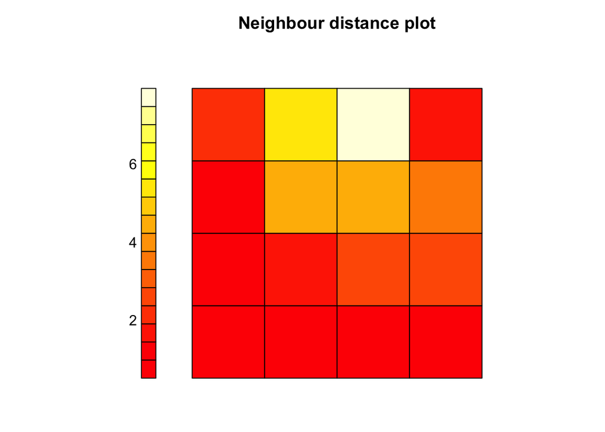

```r
# call the kohonen package
library(kohonen)

# Seed chosen to match SAS and R results
set.seed(5)

fit <- som(features, mode = "online", somgrid(4, 4, "rectangular"))

plot(fit, type = "dist.neighbour", shape = "straight")
```

kohonen

# 8 Forecasting

## 8.1 Fit an ARIMA model to a timeseries.

### a) Plot the timeseries.

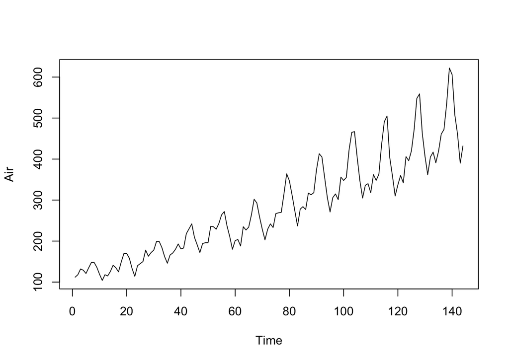

```r
# Read in new data set
air <- read.csv('/Users/air.csv')

air_series <- air$AIR

plot.ts(air_series, ylab="Air")
```

[plot.ts()](https://stat.ethz.ch/R-manual/R-devel/library/stats/html/plot.ts.html)

### b) Fit an ARIMA (0, 1, 1) model and predict 2 years (24 months).

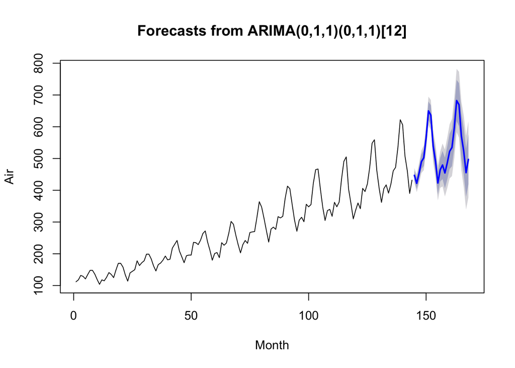

```r
a_fit <- arima(air_series, order = c(0,1,1),
               seasonal = list(order = c(0,1,1), period = 12),
               method = "ML")

# call the forecast package
library(forecast)

a_forecast <- forecast(a_fit, 24)

plot(a_forecast, xlab = "Month", ylab = "Air")
```

[arima()](https://stat.ethz.ch/R-manual/R-devel/library/stats/html/arima.html) | forecast

## 8.2 Fit a Simple Exponential Smoothing model to a timeseries.

### a) Plot the timeseries.

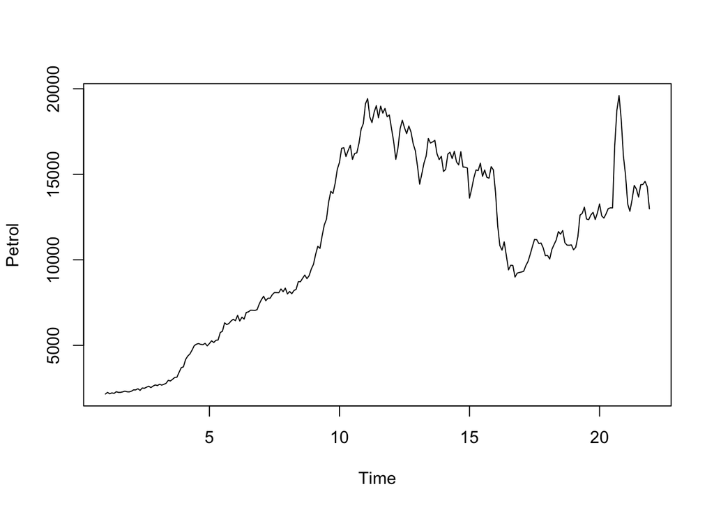

```r
# Read in new data set
usecon <- read.csv('/Users/usecon.csv')

petrol_series <- usecon$PETROL

petrol <- ts(petrol_series, frequency = 12)

plot.ts(petrol, ylab="Petrol")
```

[ts()](http://www.statmethods.net/advstats/timeseries.html) | [plot.ts()](https://stat.ethz.ch/R-manual/R-devel/library/stats/html/plot.ts.html)

### b) Fit a Simple Exponential Smoothing model, predict 2 years (24 months) out and plot predictions.

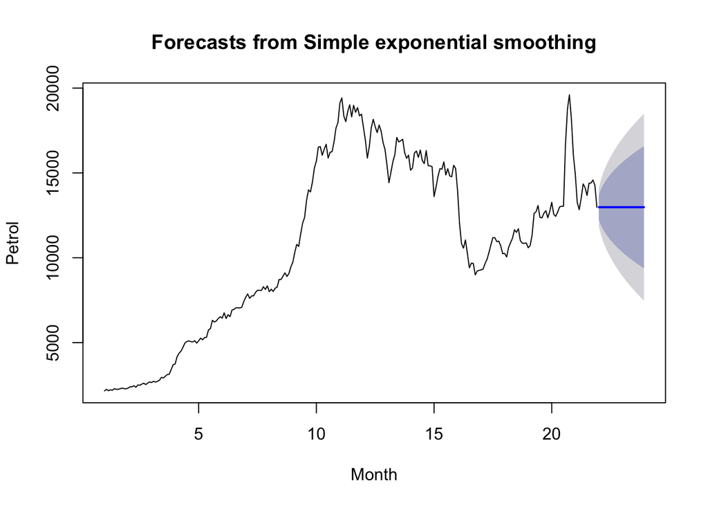

```r
# call the forecast package
library(forecast)

ses_fit <- ses(petrol, h=24, alpha = 0.9999)

plot(ses_fit, xlab = "Month", ylab = "Petrol")
```

forecast

## 8.3 Fit a Holt-Winters model to a timeseries.

### a) Plot the timeseries.

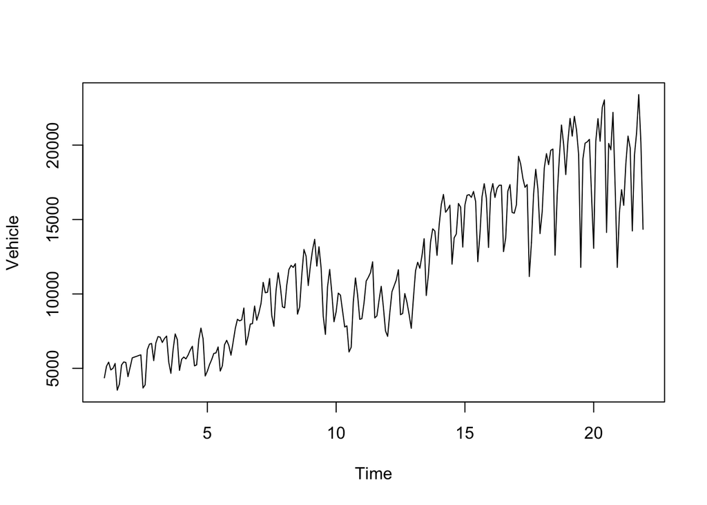

```r
vehicle_series <- usecon$VEHICLES

vehicle <- ts(vehicle_series, frequency = 12)

plot.ts(vehicle, ylab="Vehicle")
```

[ts()](http://www.statmethods.net/advstats/timeseries.html) | [plot.ts()](https://stat.ethz.ch/R-manual/R-devel/library/stats/html/plot.ts.html)

### b) Fit a Holt-Winters additive model, predict 2 years (24 months) out and plot predictions.

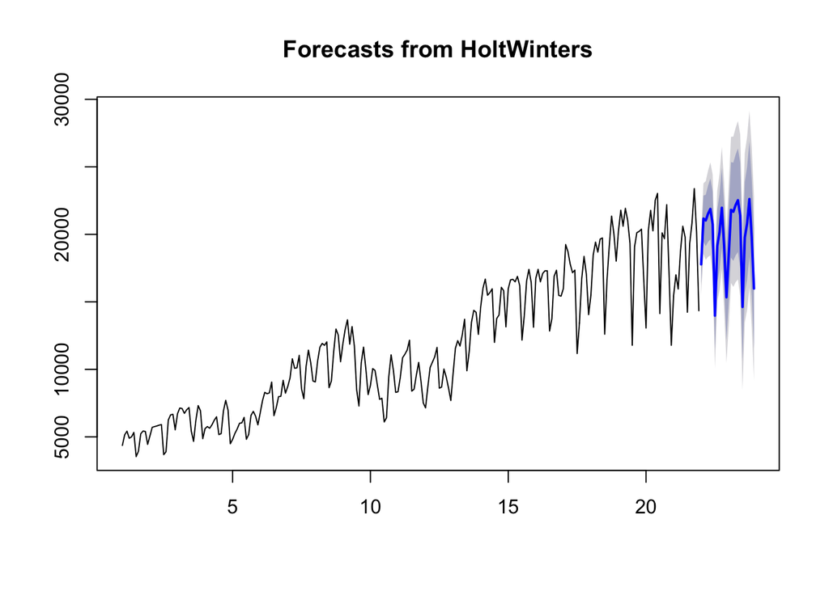

```r
# call the forecast package
library(forecast)

add_fit <- HoltWinters(vehicle, seasonal = "additive")

add_forecast <- forecast(add_fit, 24)

plot(add_forecast)
```

forecast

## 8.4 Fit a Facebook Prophet forecasting model to a timeseries.

```r
air <- read.csv('/Users/air.csv')

# call the prophet & dplyr packages
library(prophet)
library(dplyr)

air_df <- data.frame(matrix(ncol = 0, nrow = nrow(air)))

air_df$ds <- as.Date(air$DATE, format = "%m/%d/%Y")
air_df$y <- air$AIR

m <- prophet(air_df, yearly.seasonality = TRUE, weekly.seasonality = FALSE)
```

```
## Initial log joint probability = -2.46502
## Optimization terminated normally:
##   Convergence detected: absolute parameter change was below tolerance
```

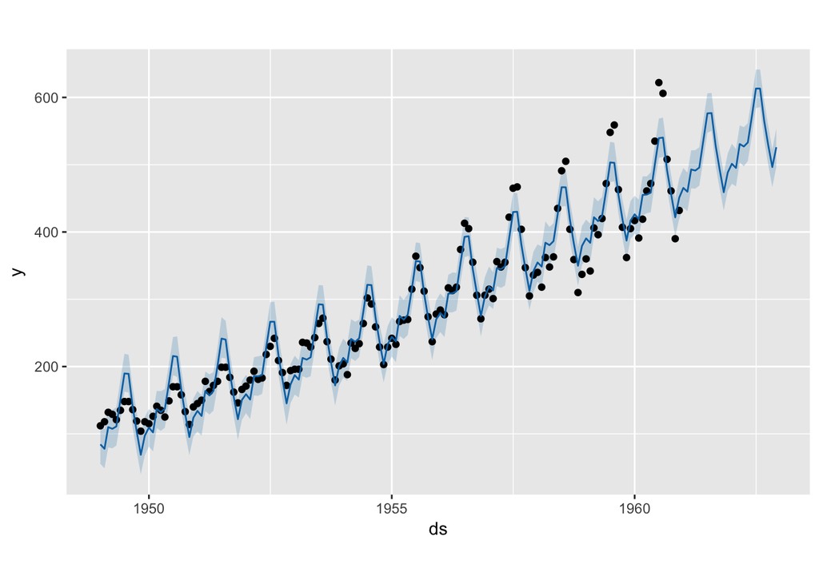

```r
future <- make_future_dataframe(m, periods = 24, freq = "month")

forecast <- predict(m, future)

plot(m, forecast)
```

Facebook Prophet R API

# 9 Model Evaluation & Selection

## 9.1 Evaluate the accuracy of regression models.

### a) Evaluation on training data.

```r
train <- read.csv('/Users/boston_train.csv')
test <- read.csv('/Users/boston_test.csv')

set.seed(29)

# Random Forest Regression Model
# call the randomForest package
library(randomForest)

rfMod <- randomForest(Target ~ ., data = train)

# Evaluation on training data
predY <- predict(rfMod, train)
predY <- unname(predY)

# Determine coefficient of determination score
r2_rf <- 1 - ( (sum((train$Target -
                       predY)**2)) / (sum((train$Target -
                                           mean(train$Target))**2)) )
print(paste0("Random forest regression model r^2 score (coefficient of determination): ", r2_rf))
```

```
## [1] "Random forest regression model r^2 score (coefficient of determination): 0.972080769152132"
```

### b) Evaluation on testing data.

```r
# Random Forest Regression Model (rfMod)

# Evaluation on testing data
predY <- predict(rfMod, test)
predY <- unname(predY)

# Determine coefficient of determination score
r2_rf <- 1 - ( (sum((test$Target -
                      predY)**2)) / (sum((test$Target -
                                          mean(test$Target))**2)) )
print(paste0("Random forest regression model r^2 score (coefficient of determination): ", r2_rf))
```

```
## [1] "Random forest regression model r^2 score (coefficient of determination): 0.886681832095677"
```

randomForest | [predict()](https://www.rdocumentation.org/packages/stats/versions/3.4.0/topics/predict) | [unname()](https://www.rdocumentation.org/packages/base/versions/3.4.0/topics/unname)

The formula used here for the coefficient of determination score is based off the Python skearn formula for [r2_score](http://scikit-learn.org/stable/modules/model_evaluation.html#r2-score-the-coefficient-of-determination). For more information about model assessment in R, please review information about the R package [caret](https://cran.r-project.org/web/packages/caret/index.html).

## 9.2 Evaluate the accuracy of classification models.

### a) Evaluation on training data.

```r
train <- read.csv('/Users/digits_train.csv')
test <- read.csv('/Users/digits_test.csv')

set.seed(29)

# Random Forest Classification Model
# call the randomForest package
library(randomForest)

rfMod <- randomForest(as.factor(Target) ~ ., data = train)

# Evaluation on training data
predY <- predict(rfMod, train)
predY <- unname(predY)

# Determine accuracy score
accuracy_rf <- (1/nrow(train)) * sum(as.numeric(predY == train$Target))
print(paste0("Random forest model accuracy: ", accuracy_rf))
```

```
## [1] "Random forest model accuracy: 1"
```

### b) Evaluation on testing data.

```r
# Random Forest Classification Model (rfMod)

# Evaluation on testing data
predY <- predict(rfMod, test)
predY <- unname(predY)

# Determine accuracy score
accuracy_rf <- (1/nrow(test)) * sum(as.numeric(predY == test$Target))
print(paste0("Random forest model accuracy: ", accuracy_rf))
```

```
## [1] "Random forest model accuracy: 0.974074074074074"
```

randomForest | [predict()](https://www.rdocumentation.org/packages/stats/versions/3.4.0/topics/predict) | [unname()](https://www.rdocumentation.org/packages/base/versions/3.4.0/topics/unname)

The formula used here for the accuracy score is based off the Python skearn formula for [accuracy_score](http://scikit-learn.org/stable/modules/model_evaluation.html#accuracy-score). For more information about model assessment in R, please review information about the R package [caret](https://cran.r-project.org/web/packages/caret/index.html).

## 9.3 Evaluation with cross validation.

### a) KFold

```r
# Notice we are using a new data set that needs to be read into the
# environment
breastcancer <- read.csv('/Users/breastcancer.csv')

# call the caret and randomForest packages
library(caret)
library(randomForest)

set.seed(29)

# Create the 5 cross validation folds
train_control <- trainControl(method = "cv", number = 5,
                              savePredictions = TRUE)

# Convert Target into a factor variable for the random forest model
breastcancer$Target <- factor(breastcancer$Target, levels = c(1,0),
                              labels = c(1, 0))

# Train the model, using the 5 cross validation folds
model <- train(Target~., data = breastcancer, trControl = train_control,
               method = "rf")

# Assess the accuracy of the model
tab <- model$pred
tab$correct <- (tab$pred == tab$obs)
tab$correct_num <- ifelse(tab$correct=="TRUE", 1, 0)
aggdata <- unname(as.matrix(aggregate(correct_num ~ Resample, tab, sum)))
aggdata <- as.numeric(aggdata[,2])
counts <- unname(table(tab$Resample))
accuracy <- c(0,0,0,0,0)
for (i in 1:5) {
  accuracy[i] <- aggdata[i]/counts[i]
}

print(paste0("Accuracy: ", round(mean(accuracy)*100, digits=2), "% +/- ",
             round(sd(accuracy)*100, digits=2), "%"))
```

```
## [1] "Accuracy: 95.77% +/- 1.68%"
```

caret | randomForest | [trainControl()](https://www.rdocumentation.org/packages/caret/versions/6.0-76/topics/trainControl)

### b) ShuffleSplit

```r
# call the caret and randomForest packages
library(caret)
library(randomForest)

set.seed(29)

X <- subset(breastcancer, select = -c(Target))
Y <- breastcancer$Target

# Create the data partition
trainIndex <- createDataPartition(Y, times = 5, p = 0.7, list = FALSE)
accuracy <- c(0, 0, 0, 0, 0)

for (i in 1:5) {
  nam <- paste("data_train", i, sep ="")
  assign(nam, breastcancer[trainIndex[,i],])
  nam <- paste("data_test", i, sep ="")
  assign(nam, breastcancer[-trainIndex[,i],])
}

data_train <- list(data_train1, data_train2, data_train3, data_train4,
                   data_train5)
data_test <- list(data_test1, data_test2, data_test3, data_test4, data_test5)

# Train the model and assess the accuracy
for (i in 1:5) {
  fit <- randomForest(as.factor(Target) ~ ., data = data_train[[i]])
  Prediction <- predict(fit, data_test[[i]])
  Prediction <- unname(Prediction)
  correct <- (data_test[[i]]$Target == Prediction)
  counts <- unname(table(correct))
  accuracy[i] <- counts[2] / sum(counts)
}

print(paste0("Accuracy: ", round(mean(accuracy)*100, digits=2), "% +/- ",
             round(sd(accuracy)*100, digits=2), "%"))
```

```
## [1] "Accuracy: 96.24% +/- 0.53%"
```

caret | randomForest | [createDataPartition()](https://www.rdocumentation.org/packages/caret/versions/6.0-76/topics/createDataPartition)

# Appendix

## 1 Built-in R Objects

#### Vectors

- [Logical](https://stat.ethz.ch/R-manual/R-devel/library/base/html/logical.html)
- [Numeric](https://stat.ethz.ch/R-manual/R-devel/library/base/html/numeric.html)
- [Integer](https://stat.ethz.ch/R-manual/R-devel/library/base/html/integer.html)
- [Complex](https://stat.ethz.ch/R-manual/R-devel/library/base/html/complex.html)
- [Character](https://stat.ethz.ch/R-manual/R-devel/library/base/html/character.html)
- [Raw](https://stat.ethz.ch/R-manual/R-devel/library/base/html/raw.html)

#### [Matrics](https://stat.ethz.ch/R-manual/R-devel/library/base/html/matrix.html)

#### [Factors](https://stat.ethz.ch/R-manual/R-devel/library/base/html/factor.html)

## 2 R packages used in this tutorial

#### [gdata](https://cran.r-project.org/web/packages/gdata/gdata.pdf)

Data manipulation

#### [rjson](https://cran.r-project.org/web/packages/rjson/rjson.pdf)

Converting R objects into JSON objects, and JSON objects into R objects

#### [ggplot2](https://cran.r-project.org/web/packages/ggplot2/ggplot2.pdf)

Visualizations and graphics

#### [dplyr](https://cran.r-project.org/web/packages/dplyr/dplyr.pdf)

Working with data frame like objects

#### [tree](https://cran.r-project.org/web/packages/tree/tree.pdf)

Decision trees models

#### [randomForest](https://cran.r-project.org/web/packages/randomForest/randomForest.pdf)

Random forest models

#### [gbm](https://cran.r-project.org/web/packages/gbm/gbm.pdf)

Gradient boosting models

#### [xgboost](https://cran.r-project.org/web/packages/xgboost/xgboost.pdf)

Extreme gradient boosting models

#### [e1071](https://cran.r-project.org/web/packages/e1071/e1071.pdf)

Support vector machine models

#### [RSNNS](https://cran.r-project.org/web/packages/RSNNS/RSNNS.pdf)

Neural network models

#### [caret](https://cran.r-project.org/web/packages/caret/caret.pdf)

Training and plotting classification and regression models

#### [kernlab](https://cran.r-project.org/web/packages/kernlab/kernlab.pdf)

Spectral clustering

#### [dbscan](https://cran.r-project.org/web/packages/dbscan/dbscan.pdf)

DBSCAN clustering

#### [kohonen](https://cran.r-project.org/web/packages/kohonen/kohonen.pdf)

Supervised and unsupervised self-organizing maps

#### [forecast](https://cran.r-project.org/web/packages/forecast/forecast.pdf)

Displaying and analyzing time series for forecasting

#### [prophet](https://facebookincubator.github.io/prophet/docs/quick_start.html#r-api)

Tools for forecasting using the Facebook Prophet model

# Alphabetical Index

## [Array](https://www.tutorialspoint.com/r/r_arrays.htm)

A one-dimensional data frame. Please see the following example of array creation and access:

```r
my_array <- c(1, 3, 5, 9)
print(my_array)
```

```
## [1] 1 3 5 9
```

```r
print(my_array[1])
```

```
## [1] 1
```

## [Data Frame](https://stat.ethz.ch/R-manual/R-devel/library/base/html/data.frame.html)

An R Data Frame is a two-dimensional tabular structure with labeled axes (rows and columns), where data observations are represented by rows and data variables are represented by columns.

## Dictionary

A dictionary is an associative array which is indexed by keys which map to values. Therefore, a dictionary is an unordered set of key:value pairs where each key is unique. In R, a dictionary can be implemented using a [named list](http://www.r-tutor.com/r-introduction/list/named-list-members). Please see the following example of named list creation and access:

```r
student <- read.csv('/Users/class.csv')
values <- student$Age
names(values) <- student$Name
print(values["James"])
```

```
## James
##    12
```

## [List](http://www.r-tutor.com/r-introduction/list)

An R list is a sequence of comma-separated objects that need not be of the same type. Please see the following example of list creation and access:

```r
list1 <- list('item1', 102)
print(list1)
```

```
## [[1]]
## [1] "item1"
##
## [[2]]
## [1] 102
```

```r
print(list1[1])
```

```
## [[1]]
## [1] "item1"
```

## [Vector](https://www.tutorialspoint.com/r/r_data_types.htm)

A vector is a one-dimensional data structure which is able to hold different classes of elements, but only one class per vector.

For more information on R packages and functions, along with helpful examples, please see [R](https://www.rdocumentation.org/).